# Case Study

Souhail Elaissaoui

```r
#install.packages("logspline")
#install.packages("fitdistrplus")
#install.packages("fossil")
```

```r
library(dplyr)
library(ggplot2)
library(knitr)
library(hexbin)
library(MASS)
library(gdata)
library(fitdistrplus)
library(logspline)
library(FactoMineR)
library(fossil)
```

# Presentation of the case study

## EasyKost

A common approach to determine the cost of products is the **should cost** method. It consists in estimating what a product should cost based on materials, labor, overhead, and profit margin. Although this strategy is very accurate, it has the drawback of being tedious and it requires expert knowledge of industrial technologies and processes. To get a quick estimation, it is possible to build a statistical model to predict the cost of products given their characteristics. With such a model, it would no longer be necessary to be an expert or to wait several days to assess the impact of a design modification, a change in supplier or a change in production site. Before builing a model, it is important to explore the data which is the aim of this case study.

## Die Casting

This study was carried out for a company that sells parts for the car industry. They build many parts themselves, but because they don’t have foundries, they don’t make die-cast parts and they need to buy them. To bid on tenders, they usually ask their supplier how much the die-cast part will cost them. However, suppliers may take time to respond and the company may lose the tender. Therefore, they want to try to use the data to estimate the price of die-casting accurately and quickly without consulting the supplier, and thus be able to respond to the call for tenders.

Some explanation for some variables. “EXW cost” : unit price, (ex-works price: no transport) “Yearly Volume”: Annual order volume: number of items ordered.

This allows for an identical line in the data except for the volume to have a different price, since in general, the purchase volume is an important cost-driver.

**1) Import and summarize the data.**

```r
diecasting <- read.csv("diecasting.csv", header = TRUE)
```

```r
glimpse(diecasting)
```

```
## Observations: 211
## Variables: 19
## $ ID                              <int> 5, 21, 38, 51, 59, 68, 75, 151...
## $ idPhoto                         <fct> dieCasting-1, dieCasting-8, di...
## $ Date                            <fct> 26/05/2016, 26/05/2016, 25/05/...
## $ Supplier                        <fct> Admiral Supplier, Admiral Supp...
## $ Supplier.Country                <fct> Italia, India, China, India, I...
## $ Yearly.Volume                   <int> 420000, 150000, 150000, 60000,...
## $ Raw.material                    <fct> AC 46000, AC 46000, AC 46000, ...
## $ Net.Weight..kg.                 <dbl> 1.022, 0.888, 0.515, 0.695, 0....
## $ Finishing                       <fct> Shotblasting, Shotblasting, Sh...
## $ Surface.envelop..LG.x.lg...mm2. <int> 32000, 38500, 22110, 21150, 17...
## $ nb.Machining.Surfaces           <int> 5, 1, 14, 27, 14, 21, 22, 10, ...
## $ nb.Threading                    <int> 0, 1, 0, 2, 2, 0, 0, 1, 2, 2, ...
## $ Over.molding                    <fct> No, No, No, No, No, No, No, No...
## $ Assembly                        <fct> No, No, No, Yes, No, No, No, Y...
## $ nb.Cavities                     <int> 4, 1, 2, 2, 2, 2, 4, 1, 0, 1, ...
## $ Cooling                         <fct> Air-cooled - Standard, Air-coo...
## $ Process                         <fct> GDC, GDC, Sand Cast, Sand Cast...
## $ nb.Cores                        <int> 3, 5, 2, 5, 3, 6, 2, 1, 0, 2, ...
## $ EXW.cost                        <dbl> 22.040, 18.170, 12.230, 7.630,...
```

**2)** **We start with univariate and bivariate descriptive statistics. Using appropriate plot(s) or summaries answer the following questions**

**2.1** How is the distribution of the cost? Comment your plot with respect to the quartiles of the cost.

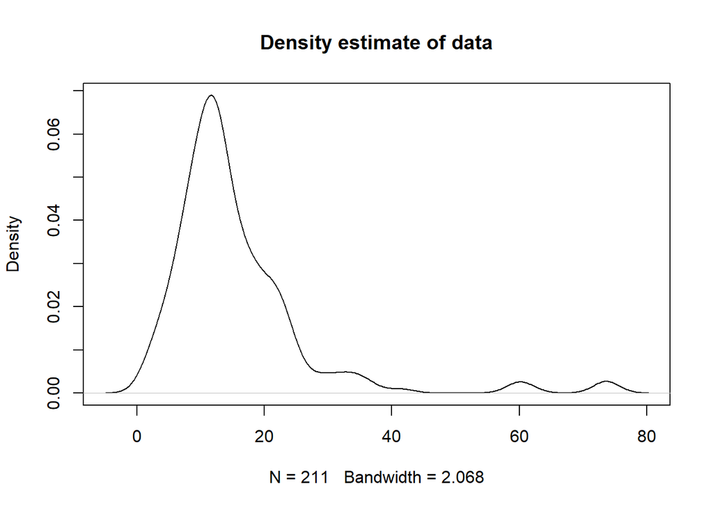

```r
x <- diecasting %>% arrange(desc(EXW.cost))
x <- x$EXW.cost
plot(density(x),main="Density estimate of data")
```

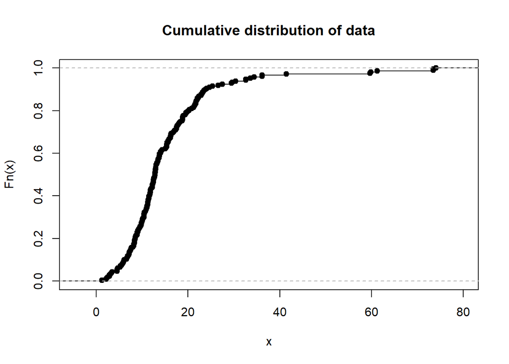

```r
plot(ecdf(x),main="Cumulative distribution of data")
```

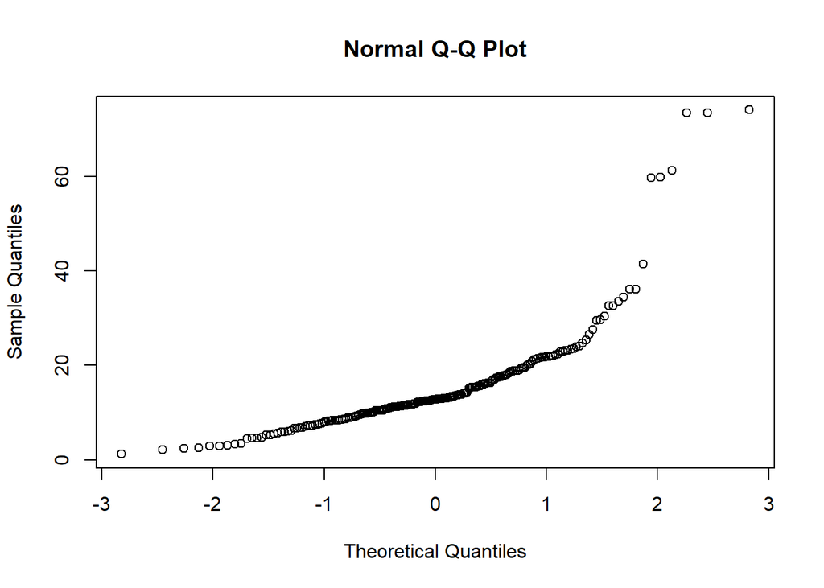

```r
qqnorm(x)
```

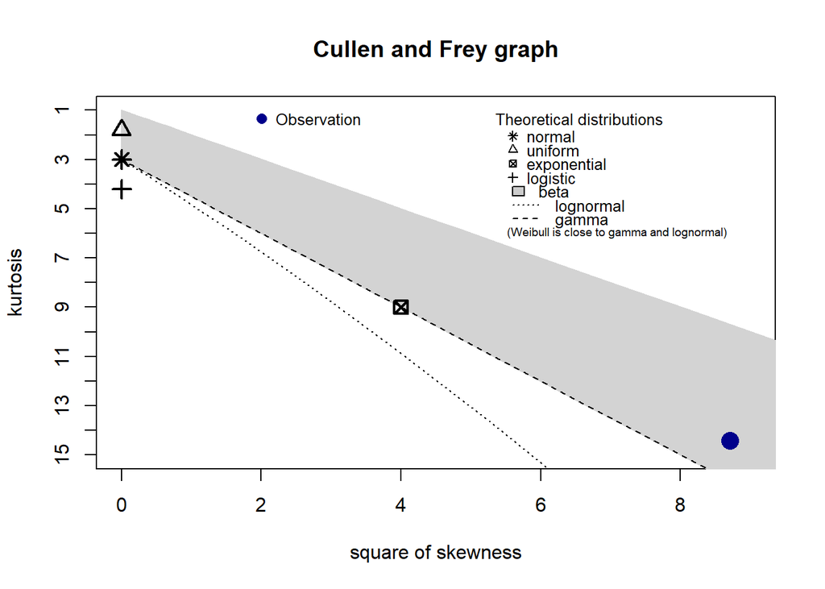

```
## summary statistics
## ------
## min:  1.23   max:  74.05
## median:  12.852
## mean:  15.54036
## estimated sd:  11.29868
## estimated skewness:  2.950702
## estimated kurtosis:  14.43287
```

```r
descdist(x, discrete = FALSE)
```

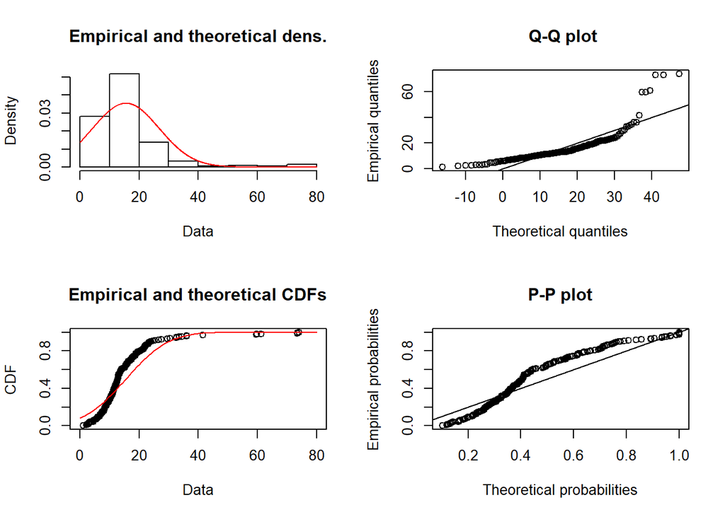

```r
fit.weibull <- fitdist(x, "weibull")
fit.norm <- fitdist(x, "norm")
plot(fit.norm)
```

The price seems to be distributed with a Beta distribution.

**2.2** Which are the most frequent suppliers?

```r
diecasting %>% group_by(Supplier) %>% summarize(total_occurence=length(Supplier)) %>% arrange(desc(total_occurence))
```

```
## # A tibble: 20 x 2
##    Supplier               total_occurence
##    <fct>                            <int>
##  1 Les espaces Supplier                19
##  2 Excalibur Supplier                  17
##  3 OneUp Supplier                      15
##  4 Admiral Supplier                    14
##  5 Alcyon Supplier                     14
##  6 Sedona Supplier                     13
##  7 Convergence Supplier                12
##  8 Hollywood Supplier                  12
##  9 Conduit Supplier                    11
## 10 Galileo Supplier                    11
## 11 Optima Supplier                     10
## 12 Carcajou Supplier                    9
## 13 Conception Supplier                  9
## 14 Nord Supplier                        8
## 15 World Supplier                       8
## 16 Imaginaire Supplier                  7
## 17 Downtown Supplier                    6
## 18 Full house Supplier                  6
## 19 MillionDollar Supplier               6
## 20 Chanceux Supplier                    4
```

The most frequent supplier are “Les espaces Supplier” with 19 occurences, and “Excalibur Supplier” with 17 occurences.

**2.3** _Does the cost depend on the Net weight? on Yearly Volume? Does this make sense to you? Can you explain (from a business point of view) the form of the relationship for high volume values.

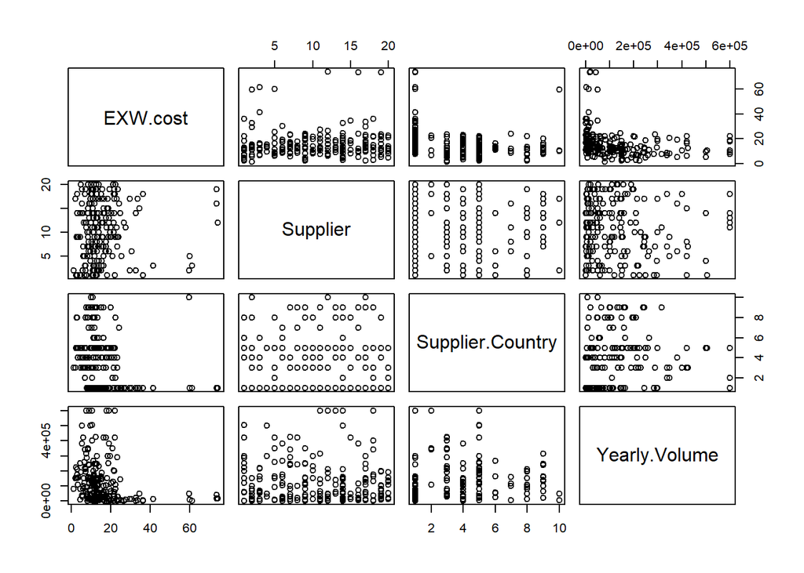

```r
pairs(diecasting[c(19,4,5,6)])
```

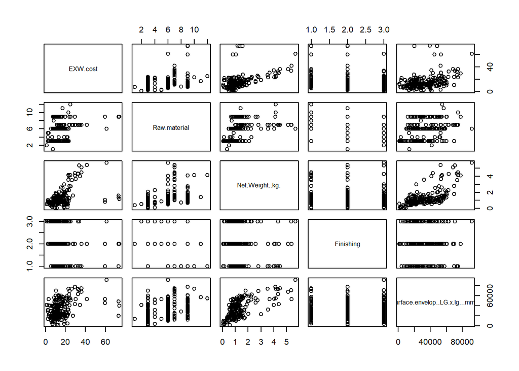

```r
pairs(diecasting[c(19,7,8,9,10)])
```

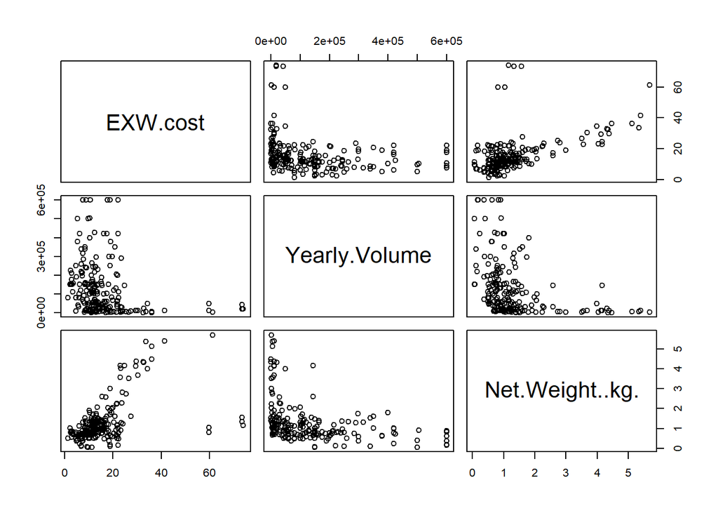

```r
pairs(diecasting[c(19,6,8)])
```

With the scatterplots of all the variables, we can see that there might be a dependence between the Price and the Volume, and between the Price and the net Weigth.

But these are not the only dependecies that we can see:

```r
diecasting %>% group_by(Supplier) %>% summarize(mean_price=mean(EXW.cost)) %>%  arrange(desc(mean_price))
```

```
## # A tibble: 20 x 2
##    Supplier               mean_price
##    <fct>                       <dbl>
##  1 Carcajou Supplier            20.4
##  2 Nord Supplier                19.0
##  3 Sedona Supplier              18.9
##  4 Hollywood Supplier           18.8
##  5 Conception Supplier          18.2
##  6 MillionDollar Supplier       17.8
##  7 Alcyon Supplier              17.2
##  8 OneUp Supplier               16.3
##  9 Galileo Supplier             16.0
## 10 Optima Supplier              14.8
## 11 Conduit Supplier             14.6
## 12 Full house Supplier          13.8
## 13 Convergence Supplier         13.7
## 14 Excalibur Supplier           13.7
## 15 Imaginaire Supplier          13.6
## 16 Les espaces Supplier         13.4
## 17 World Supplier               13.1
## 18 Chanceux Supplier            13.0
## 19 Downtown Supplier            12.6
## 20 Admiral Supplier             12.0
```

```r
diecasting %>% group_by(Raw.material) %>% summarize(mean_price=mean(EXW.cost)) %>% arrange(desc(mean_price))
```

```
## # A tibble: 12 x 2
##    Raw.material mean_price
##    <fct>             <dbl>
##  1 Al 5403           24.7
##  2 Al 4235           23.8
##  3 Al 5400           22.9
##  4 Al 5371           19.2
##  5 Al 5401           17.0
##  6 AC 46100          15.2
##  7 Al 4234           13.9
##  8 AC 46000          12.2
##  9 Al 4285            8.36
## 10 AC 43500           7.27
## 11 Al 4215            2.83
## 12 AC 43501           1.23
```

The price varies a lot depending on which supplier and on the raw material used. Which seems logical as the suppliers might charge different price, and raw material have also different prices.

**2.4** Let $n=25$. Generate variables $X$ and $Y$ by drawing observations from independent gaussian distributions with mean $\mu=(0)_{1 \times 2}$ and covariance matrix $\text{Id}_{2 \times 2}$. Compute the value of the correlation coefficient. Repeat the process 100 times and take the quantile at 95% of this empirical distribution (under the null hypothesis of no linear relationship) of the correlation coefficient. Comment the results. What should be learned from this experience?

```r
cor <- NULL

for (i in 1:100) {
X <- mvrnorm(25,c(0,0),diag(2))
Y <- mvrnorm(25,c(0,0),diag(2))
test <- cor.test(X,Y)
cor <- c(cor,abs(test$estimate[["cor"]]))
}

quantile(cor, 0.95)
```

```
##       95%
## 0.2291238
```

From independant random distribution we see that we can find a correlation coefficient superior than 0.20 which is pretty high. The idea here is reminiscent of what you can see if you compute a correlation coefficient between two independent variables but on a small sample size. You can have large values even if the variables are orthogonal.

**2.5** Does the cost depend on the Cooling ?

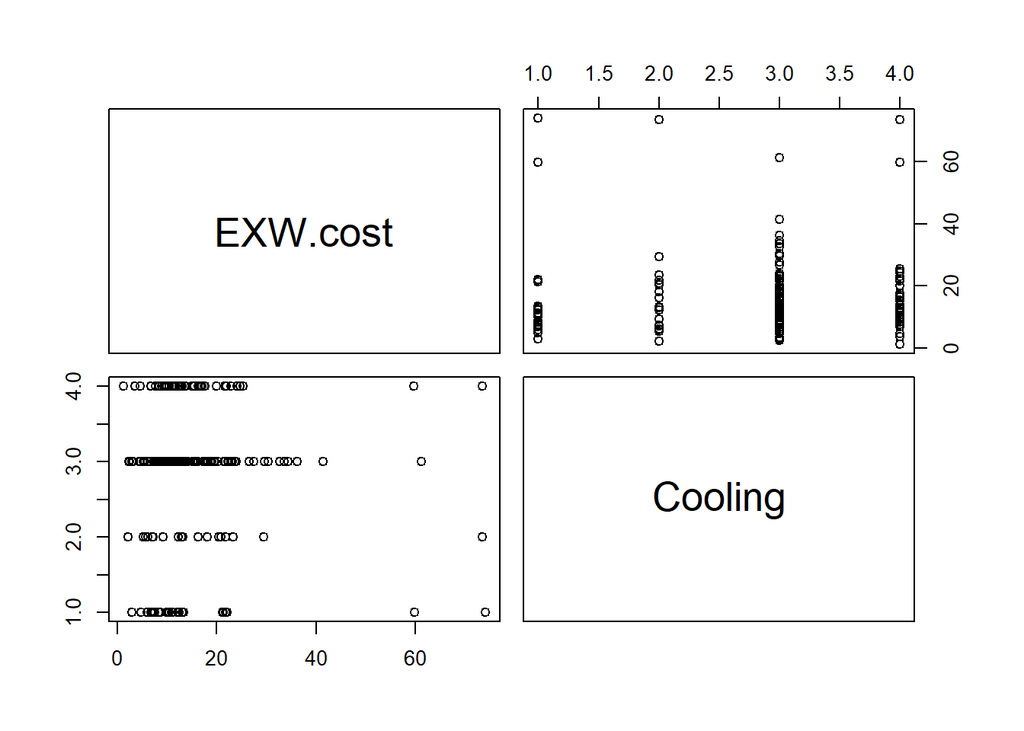

```r
pairs(diecasting[c(19,16)])
```

Yes with the scatterplot we can see that there is a dependency between the Cooling and the Price.

**2.6** Which is the less expensive Supplier?

```r
diecasting %>% group_by(Supplier) %>% summarize(mean_price=mean(EXW.cost)) %>%  arrange(mean_price)
```

```
## # A tibble: 20 x 2
##    Supplier               mean_price
##    <fct>                       <dbl>
##  1 Admiral Supplier             12.0
##  2 Downtown Supplier            12.6
##  3 Chanceux Supplier            13.0
##  4 World Supplier               13.1
##  5 Les espaces Supplier         13.4
##  6 Imaginaire Supplier          13.6
##  7 Excalibur Supplier           13.7
##  8 Convergence Supplier         13.7
##  9 Full house Supplier          13.8
## 10 Conduit Supplier             14.6
## 11 Optima Supplier              14.8
## 12 Galileo Supplier             16.0
## 13 OneUp Supplier               16.3
## 14 Alcyon Supplier              17.2
## 15 MillionDollar Supplier       17.8
## 16 Conception Supplier          18.2
## 17 Hollywood Supplier           18.8
## 18 Sedona Supplier              18.9
## 19 Nord Supplier                19.0
## 20 Carcajou Supplier            20.4
```

The less expensive supplier is “Admiral Supplier”

**3)** **One important point in exploratory data analysis consists in identifying potential outliers.**

**3.1** Could you give points which are suspect regarding the Cost variable. Give the characteristics (other features) of the observations. We could keep them but keep in mind their presence and check if results are not too affected by these points.

```r
Boxplot <- boxplot.stats(diecasting$EXW.cost)
Boxplot
```

```
## $stats
## [1]  1.230  9.565 12.852 18.545 30.391
##
## $n
## [1] 211
##
## $conf
## [1] 11.87523 13.82877
##
## $out
##  [1] 36.160 32.630 59.670 61.224 41.483 59.850 74.050 32.648 34.401 73.430
## [11] 33.586 36.170 73.440
```

```r
outlier_values <- Boxplot$out
outlier_values
```

```
##  [1] 36.160 32.630 59.670 61.224 41.483 59.850 74.050 32.648 34.401 73.430
## [11] 33.586 36.170 73.440
```

```r
diecasting %>% filter(EXW.cost %in% outlier_values)
```

```
##     ID       idPhoto       Date               Supplier Supplier.Country
## 1  200  dieCasting-8 24/05/2013       Admiral Supplier            China
## 2  156 dieCasting-10 24/04/2015        Alcyon Supplier            China
## 3  199 dieCasting-11 27/07/2016        Alcyon Supplier          Vietnam
## 4  110 dieCasting-11 19/06/2013      Carcajou Supplier            China
## 5  153  dieCasting-9 09/06/2015      Carcajou Supplier            China
## 6  152  dieCasting-8 29/02/2016    Conception Supplier            China
## 7  198  dieCasting-3 13/01/2016     Hollywood Supplier            China
## 8  155  dieCasting-1 15/07/2013   Les espaces Supplier            China
## 9  154  dieCasting-3 31/10/2011 MillionDollar Supplier            China
## 10 109  dieCasting-6 15/04/2015          Nord Supplier            China
## 11 112  dieCasting-7 02/11/2008         OneUp Supplier            China
## 12 111  dieCasting-8 21/10/2009        Optima Supplier            China
## 13 108  dieCasting-4 10/11/2016        Sedona Supplier            China
##    Yearly.Volume Raw.material Net.Weight..kg.    Finishing
```

[output cut: 55 more lines]

We can see that the outliers seems to all have a supplier in China or Vietnam.

**3.2** Inspect the variable nb Threading, in views of its values of what could you suggest?

```r
summary(diecasting$nb.Threading)
```

```
##    Min. 1st Qu.  Median    Mean 3rd Qu.    Max.
##   0.000   0.000   1.000   1.583   2.000  23.000
```

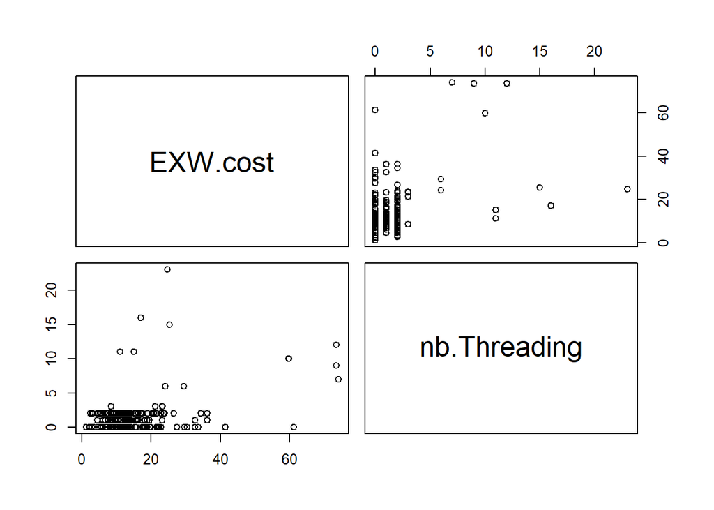

```r
pairs(diecasting[c(19,12)])
```

We can suggest that this variable might not be used in our dataset. The Threading number is highly distributed in a quantitative way and can hardly represent the data when taken in a quantitative way.

**4)** **Perform a PCA on the dataset DieCast**.

```r
res.pca <- PCA(diecasting , quali.sup = c(1,2,3,4,5,7,9,12,13,14,16,17,18), scale.unit = TRUE, ncp = 4)
```

[figure not shown]

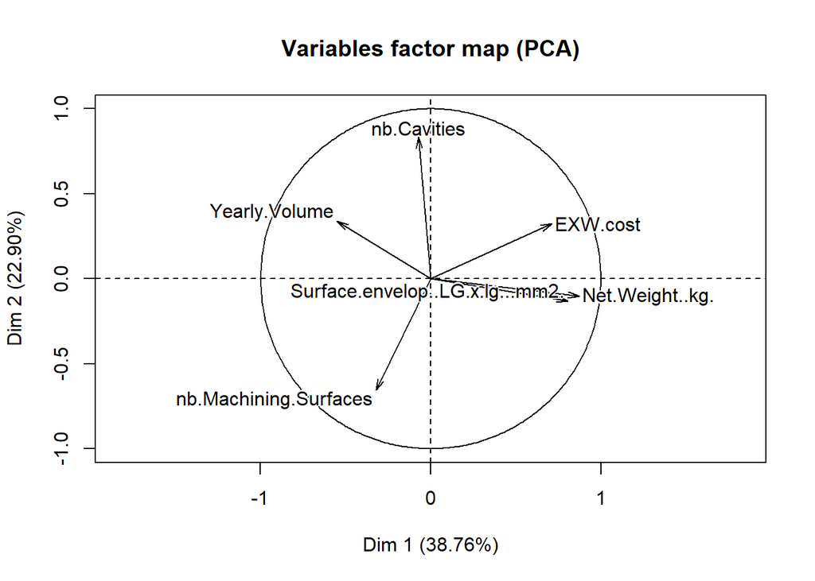

```r
 summary(res.pca, nbelements = 2, ncp = 4)
```

```
##
## Call:
## PCA(X = diecasting, scale.unit = TRUE, ncp = 4, quali.sup = c(1,
##      2, 3, 4, 5, 7, 9, 12, 13, 14, 16, 17, 18))
##
##
## Eigenvalues
##                        Dim.1   Dim.2   Dim.3   Dim.4   Dim.5   Dim.6
## Variance               2.325   1.374   0.762   0.726   0.504   0.309
## % of var.             38.757  22.902  12.695  12.099   8.401   5.145
## Cumulative % of var.  38.757  61.660  74.355  86.455  94.855 100.000
##
## Individuals (the 2 first)
##                                     Dist    Dim.1    ctr   cos2    Dim.2
## 1                               |  2.488 | -0.435  0.038  0.031 |  1.626
## 2                               |  1.899 |  0.368  0.028  0.038 |  0.639
##                                    ctr   cos2    Dim.3    ctr   cos2
## 1                                0.912  0.427 |  1.568  1.530  0.397 |
## 2                                0.141  0.113 |  0.976  0.593  0.264 |
##                                  Dim.4    ctr   cos2
## 1                                0.515  0.173  0.043 |
## 2                               -1.136  0.843  0.358 |
##
## Variables (the 2 first)
##                                    Dim.1    ctr   cos2    Dim.2    ctr
## Yearly.Volume                   | -0.550 12.999  0.302 |  0.338  8.336
## Net.Weight..kg.                 |  0.872 32.669  0.760 | -0.103  0.771
##                                   cos2    Dim.3    ctr   cos2    Dim.4
## Yearly.Volume                    0.115 |  0.603 47.702  0.363 |  0.458
## Net.Weight..kg.                  0.011 |  0.163  3.490  0.027 |  0.118
##                                    ctr   cos2
## Yearly.Volume                   28.887  0.210 |
## Net.Weight..kg.                  1.927  0.014 |
##
## Supplementary categories (the 2 first)
##                                     Dist    Dim.1   cos2 v.test    Dim.2
## ID 1                            |  1.994 |  0.524  0.069  0.343 | -0.134
## ID 2                            |  1.355 |  0.079  0.003  0.052 | -0.650
##                                   cos2 v.test    Dim.3   cos2 v.test
## ID 1                             0.005 -0.114 |  0.966  0.235  1.107 |
## ID 2                             0.230 -0.555 | -0.795  0.344 -0.911 |
##                                  Dim.4   cos2 v.test
## ID 1                             1.403  0.495  1.647 |
## ID 2                            -0.033  0.001 -0.039 |
```

**4.1** Explain briefly what are the aims of PCA and how categorical variables are handled?_

Principal Component Analysis is a dimension-reduction tool used to solve Multivariate Analysis problem. We find the best variables that represent the data the most and we project the dataset into these most respresentative variables. Categorical variables are handled by projecting the categories at the barycentre of the observations which take the categories, but there are more appropriate techniques to deal with mixed data types, namely Multiple Factor Analysis for mixed data

**4.2** Compute the correlation matrix between the variables and comment it with respect to the correlation circle.

```r
#round(res.pca$var$cos2,2)
#round(res.pca$var$contrib,2)
cor(diecasting[-c(1,2,3,4,5,7,9,12,13,14,16,17,18)])
```

```
##                                 Yearly.Volume Net.Weight..kg.
## Yearly.Volume                      1.00000000      -0.3542170
## Net.Weight..kg.                   -0.35421703       1.0000000
## Surface.envelop..LG.x.lg...mm2.   -0.29165887       0.6615803
## nb.Machining.Surfaces              0.01024961      -0.1823458
## nb.Cavities                        0.16333438      -0.1386149
## EXW.cost                          -0.23883117       0.5045601
##                                 Surface.envelop..LG.x.lg...mm2.
## Yearly.Volume                                        -0.2916589
## Net.Weight..kg.                                       0.6615803
## Surface.envelop..LG.x.lg...mm2.                       1.0000000
## nb.Machining.Surfaces                                -0.1456057
## nb.Cavities                                          -0.1228921
## EXW.cost                                              0.3869538
##                                 nb.Machining.Surfaces nb.Cavities
## Yearly.Volume                              0.01024961   0.1633344
## Net.Weight..kg.                           -0.18234585  -0.1386149
## Surface.envelop..LG.x.lg...mm2.           -0.14560569  -0.1228921
## nb.Machining.Surfaces                      1.00000000  -0.2545552
## nb.Cavities                               -0.25455524   1.0000000
## EXW.cost                                  -0.22821048   0.1851150
##                                   EXW.cost
## Yearly.Volume                   -0.2388312
## Net.Weight..kg.                  0.5045601
## Surface.envelop..LG.x.lg...mm2.  0.3869538
## nb.Machining.Surfaces           -0.2282105
## nb.Cavities                      0.1851150
## EXW.cost                         1.0000000
```

-The Yearly Volume is slightly positively correlated with nb.Cavities, and is negatively correlated with the cost, weigth and Surface. Indeed, in the correlation circle, nb.Cavities and Volume are relatively close to each other, meanwhile Volume and cost are relatively opposite. Cost, Weigth and Surface are close from each other. But here the arrows are not very long, which shows that the projection is not perfect and we have lost a fraction of the data.

-The net Weigth is positively correlated with the surface Enveloppe and the Cost, as the correlation coeficient is higher than 0.5 and the arrow are close. The Weigth is negatively correlated with the Volume. Which means that an observation with high Weigth will have a high surface enveloppe and a high cost, but a low Volume.

**4.3** On what kind of relationship PCA focuses? Is it a problem?

PCA is a linear dimensionality reduction methods, thus it assumes that there is a linear relationship between the variables. PCA indeed works optimally only in the situation where the correlations are linear, which is most of the time an approximation. It can be a problem if the data has non-linear relationship. In that case we can try a transformation that will make them somehow linear.

**4.4** Give the the R object with the two principal components which are the synthetic variables the most correlated to all the variables.

```r
res.pca$ind$coord[,c(1,2)]
```

```
##            Dim.1        Dim.2
## 1   -0.434608630  1.626297630
## 2    0.368089066  0.638621496
## 3   -0.949474613 -0.117871145
## 4   -1.195368874 -1.371109681
## 5   -1.206436718 -0.291494353
## 6   -1.003866480 -0.748014908
## 7   -1.340642934 -0.474624319
## 8   -1.153304929  0.103606693
## 9   -0.192539221 -1.041448932
## 10   4.189570181 -0.780290476
## 11   0.528983548 -0.692475015
## 12   0.208896558  1.823643504
## 13  -0.958314597  0.004026023
## 14  -1.113564166  0.017180498
```

[output cut: 197 more lines]

```r
res.pca$eig
```

```
##        eigenvalue percentage of variance cumulative percentage of variance
## comp 1  2.3254489              38.757482                          38.75748
## comp 2  1.3741335              22.902226                          61.65971
## comp 3  0.7617294              12.695491                          74.35520
## comp 4  0.7259603              12.099339                          86.45454
## comp 5  0.5040358               8.400597                          94.85513
## comp 6  0.3086920               5.144867                         100.00000
```

```r
sum(res.pca$eig[,1])
```

```
## [1] 6
```

The sum of all the eigevalue gives a variance of 6. The eigenvalue of each dimension explains the percentage of variance explained by the dimension. The two first dimensions have eigenvalues superior to 1, and then each of these two principal components explains more than a original variable. The two first dimesnions explains 61% of the variance which can be somehow satisfying.

**5)** **Clustering**

**5.1)** Principal components methods such as PCA is often used as a pre-processing step before applying a clustering algorithm, explain the rationale of this approach and how many components you should keep.

Clustering is used to retrieve classes of individuals, but some clustering algorithms, as the K-means clustering, requires to choose the number of clusters. That’s why it is interesting to run a PCA on the data to help choose the number of cluster to run the clustering algorithm with. Here, by the PCA, we can see that the data are well represented by five dimensions (95% variance explained by 5 dimensiosn) . thus we could keep five components to run this clustering algorithm with K-means method.

**5.2)** To simultaneously take into account quantitative and categorical variables in the clustering you should use the clustering on the results of the FAMD ones. FAMD stands for Factorial Analysis of Mixed Data and is a PCA dedicated to mixed data. Explain what will be the impacts of such an analysis on the results?_

FAMD is a principal component method dedicated to explore data with both continuous and categorical variables. This ensures to balance the influence of both continous and categorical variables in the analysis. It means that both variables are on a equal foot to determine the dimensions of variability. Using FAMD instead of standard PCA will change the dimensiosn of variability as the qualitative variables do certainly influence the price. Thus there will be more variables taken into account.

**5.3)** Perform the FAMD, and keep the principal components you want for the clustering.

```r
diecasting_FAMD <- diecasting[-c(1,2,3)]
#glimpse(diecasting_FAMD)
res.famd <- FAMD(diecasting_FAMD, ncp = 45, graph = FALSE)#, sup.var = c(13,9,8))
res.famd$eig
```

```
##         eigenvalue percentage of variance
## comp 1   4.2001307              7.5002334
## comp 2   3.2642259              5.8289748
## comp 3   2.5086700              4.4797678
## comp 4   1.8149545              3.2409902
## comp 5   1.7700184              3.1607471
## comp 6   1.7645427              3.1509691
## comp 7   1.6623731              2.9685233
## comp 8   1.6157895              2.8853383
## comp 9   1.4987567              2.6763512
## comp 10  1.4326577              2.5583173
## comp 11  1.3863320              2.4755929
## comp 12  1.3701730              2.4467376
## comp 13  1.3323706              2.3792332
## comp 14  1.2960085              2.3143008
## comp 15  1.2648418              2.2586460
## comp 16  1.2417550              2.2174197
## comp 17  1.2055771              2.1528162
## comp 18  1.1824084              2.1114437
## comp 19  1.1135686              1.9885153
## comp 20  1.0906305              1.9475545
## comp 21  1.0810229              1.9303981
## comp 22  1.0622793              1.8969273
## comp 23  1.0449314              1.8659489
## comp 24  1.0028279              1.7907642
## comp 25  1.0008527              1.7872369
## comp 26  0.9787238              1.7477211
## comp 27  0.9529316              1.7016635
## comp 28  0.9311764              1.6628149
## comp 29  0.9130830              1.6305053
## comp 30  0.8713108              1.5559121
## comp 31  0.8673199              1.5487856
## comp 32  0.8185597              1.4617137
## comp 33  0.7450881              1.3305145
## comp 34  0.7173261              1.2809395
## comp 35  0.7001349              1.2502409
## comp 36  0.6755609              1.2063588
## comp 37  0.6529862              1.1660468
## comp 38  0.6499813              1.1606810
## comp 39  0.6202799              1.1076428
```

[output cut: 37 more lines]

```
## comp 31                         79.861150
## comp 32                         81.322864
## comp 33                         82.653379
## comp 34                         83.934318
## comp 35                         85.184559
## comp 36                         86.390918
## comp 37                         87.556965
## comp 38                         88.717646
## comp 39                         89.825288
## comp 40                         90.852111
## comp 41                         91.800543
## comp 42                         92.679308
## comp 43                         93.515637
## comp 44                         94.303691
## comp 45                         95.049155
```

Running the FAMD, we can see that 95% of the variance is kept only if we use at least the first 45 dimensions

**5.4)** Perfom a kmeans algorithm on the selected principal components of FAMD. To select how many cluster you are keeping, you can represent the evolution of the ratio between/total intertia. Justify your choices.

```r
ratio <- 0
for (i in 1 : 100) {
res.kmeans <- kmeans(res.famd$ind$coord, i, nstart=100)
ratio[i] <- res.kmeans$betweenss/res.kmeans$totss
}
```

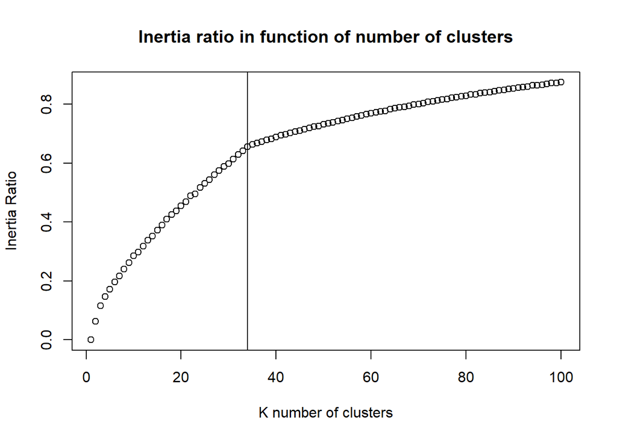

```r
plot(1:100,ratio,main="Inertia ratio in function of number of clusters", xlab="K number of clusters", ylab="Inertia Ratio")
abline(v = 34)
```

we want to have a high between class inertia and a little within class inertia, then we have to choose an appropriate number of clusters. For k less than k=34, the between class inertia/total inertia ratio tends to increase quickly, then for k superior than 34, the ratio remain less changing as compared to other k’s. So for this data k=34 should be a good choice for number of clusters. The number k=34 is called the Elbow.

**5.5)** To Describe the clusters, you can use catdes function, by concatenating your dataset to the variable specifying in which cluster each observation is and indicating that you want to describe this variable (that must be as a factor).

```r
res.kmeans <- kmeans(res.famd$ind$coord, 34, nstart=100)
don.comp <-cbind.data.frame(diecasting_FAMD,classe=factor(res.kmeans$cluster))
res.catdes <- catdes(don.comp, num.var = ncol(don.comp))
res.catdes$test.chi
```

```
##                        p.value  df
## Supplier          0.000000e+00 627
## Raw.material     1.784475e-198 363
## Supplier.Country  2.589445e-98 297
## Process           2.631364e-03  66
## Over.molding      2.745385e-02  33
```

First, we can see the categorical variables that most represent the clustering parameters.

Then we have a description of each cluster by all the categorical variables

```r
res.catdes$category
```

```
## $`1`
##                       Cla/Mod Mod/Cla    Global     p.value   v.test
## Raw.material=AC 43501     100     100 0.4739336 0.004739336 2.824237
##
## $`2`
##                            Cla/Mod Mod/Cla  Global      p.value   v.test
## Supplier=Conduit Supplier 72.72727     100 5.21327 1.936741e-12 7.038964
##
## $`3`
##                              Cla/Mod Mod/Cla    Global      p.value
## Supplier=OneUp Supplier    73.333333   68.75  7.109005 7.722993e-12
## Supplier=Carcajou Supplier 55.555556   31.25  4.265403 1.431401e-04
## Over.molding=No            10.000000   93.75 71.090047 3.071396e-02
## Supplier.Country=India     20.000000   31.25 11.848341 3.281226e-02
## Raw.material=AC 46000      13.235294   56.25 32.227488 4.422433e-02
## Over.molding=Yes            1.639344    6.25 28.909953 3.071396e-02
##                               v.test
## Supplier=OneUp Supplier     6.843595
## Supplier=Carcajou Supplier  3.802678
## Over.molding=No             2.160759
## Supplier.Country=India      2.134373
## Raw.material=AC 46000       2.011958
## Over.molding=Yes           -2.160759
##
## $`4`
##                             Cla/Mod Mod/Cla     Global      p.value
## Raw.material=Al 4215     100.000000     100  0.9478673 4.513654e-05
## Supplier.Country=Romania  14.285714     100  6.6350711 4.107425e-03
## Process=HPDC               4.444444     100 21.3270142 4.468517e-02
##                            v.test
## Raw.material=Al 4215     4.079480
## Supplier.Country=Romania 2.869792
## Process=HPDC             2.007606
##
## $`5`
##                                 Cla/Mod   Mod/Cla    Global      p.value
## Supplier=Imaginaire Supplier 100.000000 100.00000  3.317536 2.993145e-13
## Raw.material=Al 5371           9.090909  57.14286 20.853081 4.071609e-02
##                                v.test
## Supplier=Imaginaire Supplier 7.294705
```

[output cut: 204 more lines]

```
## Supplier.Country=Mexico 100.000000     100  1.895735 1.245948e-08
## Raw.material=Al 5371      9.090909     100 20.853081 1.691387e-03
## Cooling=Standard          0.000000       0 54.976303 3.966531e-02
##                            v.test
## Supplier.Country=Mexico  5.693317
## Raw.material=Al 5371     3.139669
## Cooling=Standard        -2.057217
##
## $`33`
##                           Cla/Mod Mod/Cla   Global      p.value   v.test
## Supplier=Alcyon Supplier 71.42857     100 6.635071 2.578795e-14 7.617878
##
## $`34`
##                            Cla/Mod Mod/Cla   Global      p.value   v.test
## Supplier=Chanceux Supplier     100     100 1.895735 1.245948e-08 5.693317
```

Then we have the global description of the clustering variable by the quantitative variables

```r
res.catdes$quanti.var
```

```
##                                      Eta2      P-value
## nb.Threading                    0.7158053 3.022266e-33
## Net.Weight..kg.                 0.6464368 1.587068e-25
## EXW.cost                        0.5759846 2.651186e-19
## nb.Cavities                     0.3932452 5.014427e-08
## Surface.envelop..LG.x.lg...mm2. 0.3832458 1.450408e-07
## nb.Cores                        0.2975933 3.424604e-04
## Yearly.Volume                   0.2429880 1.369552e-02
```

Finally we have the description of each category of the clustering variable by the quantitative variable.

```r
res.catdes$quanti
```

```
## $`1`
## NULL
##
## $`2`
## NULL
##
## $`3`
## NULL
##
## $`4`
##             v.test Mean in category Overall mean sd in category Overall sd
## nb.Cores -2.089596                0     3.066351              0   2.080229
##             p.value
## nb.Cores 0.03665414
##
## $`5`
##                 v.test Mean in category Overall mean sd in category
## Yearly.Volume 1.975354         230935.4     127232.7       235269.1
##               Overall sd    p.value
## Yearly.Volume   140925.2 0.04822799
##
## $`6`
## NULL
##
## $`7`
## NULL
##
## $`8`
##            v.test Mean in category Overall mean sd in category Overall sd
## nb.Cores 3.099013         5.666667     3.066351       2.494438   2.080229
##              p.value
## nb.Cores 0.001941665
##
## $`9`
## NULL
##
## $`10`
## NULL
##
## $`11`
```

[output cut: 122 more lines]

```
##                       sd in category Overall sd     p.value
## nb.Cavities                 2.449490   3.554408 0.005902624
## nb.Machining.Surfaces       3.699662   7.680372 0.028348095
##
## $`33`
##                  v.test Mean in category Overall mean sd in category
## Yearly.Volume -2.087602          36215.2     127232.7        47233.7
##               Overall sd    p.value
## Yearly.Volume   140925.2 0.03683372
##
## $`34`
##                                    v.test Mean in category Overall mean
## Surface.envelop..LG.x.lg...mm2. -2.269634         13582.75     33282.38
##                                 sd in category Overall sd    p.value
## Surface.envelop..LG.x.lg...mm2.       5253.953   17484.65 0.02322982
```

**5.6)** Comment the results and describe precisely one cluster._

Then we can see which the categorical variables that are the most represented in each cluster. When the V-test value is positive, it means that the observations with this specific value of the categorical variable are well represented in this cluster, while if it is negative, the variable do not represent the population of this cluster.

Finally, we have, for each cluster, the quantitative variables that most caracterise it. When we see “NULL”, it means that no quantitative variable caracterise the cluster.

Let’s describe the cluster “23”:

```r
res.catdes$category$`23`
```

```
##                               Cla/Mod Mod/Cla   Global      p.value
## Supplier=Convergence Supplier      75     100 5.687204 1.144871e-13
##                                 v.test
## Supplier=Convergence Supplier 7.423011
```

```r
res.catdes$quanti$`23`
```

[output not shown]

**5.7)** If someone asks you why you have selected k components to perform the clustering and not k+1 or k-1, what is your answer? (could you suggest a strategy to assess the stability of the approach? are there many differences between the clustering obtained on k components or on the initial data). You can have a look at the Rand Index.

I selected k components because k=34 corresponds to the right number of clusters by the Elbow method. Indeed, while plotting the inertia ratio, it is the point in which the curve change in its coefficient.

On the initial data, the clustering must omit the qualitative variables, which is a loss.

To assess the stability of the Elow approach, let’s try to minimize the AIC

```r
aic.res <- 0
kmeansAIC = function(fit){

m = ncol(fit$centers)
n = length(fit$cluster)
k = nrow(fit$centers)
D = fit$tot.withinss
return(D + 2*m*k)
}
for (i in 1 : 100) {
res.kmeans <- kmeans(res.famd$ind$coord, i, nstart=100)
aic.res[i] <- kmeansAIC(res.kmeans)
}
```

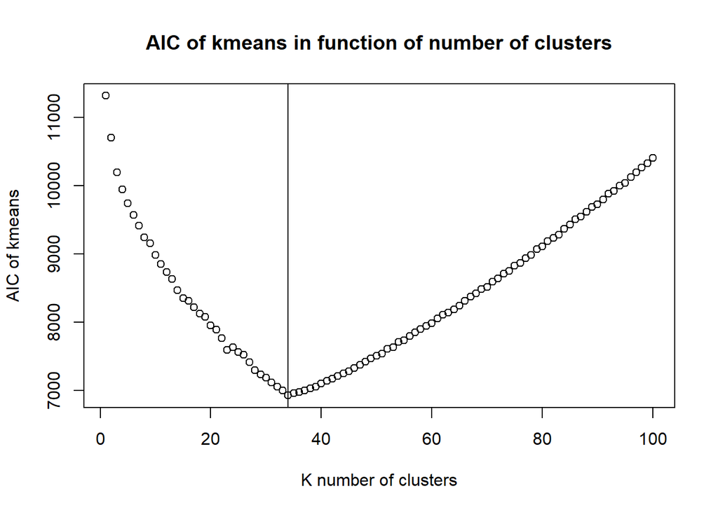

```r
plot(1:100,aic.res,main="AIC of kmeans in function of number of clusters", xlab="K number of clusters", ylab="AIC of kmeans")

abline(v = 34)
```

By minimizing the AIC, we have the same result for k=34.

```r
initial.kmeans <- kmeans(diecasting_FAMD[-c(1,2,4,6,10,11,13,14)], 34)
rand.index(initial.kmeans$cluster, res.kmeans$cluster)
```

```
## [1] 0.9628978
```

**6) The methodology that you have used to describe clusters can also be used to describe a categorical variable, for instance the supplier country. Use the function catdes and explain how this information can be useful for the company.**

```r
catdes(diecasting_FAMD, 2)
```

```
##
## Link between the cluster variable and the categorical variables (chi-square test)
## =================================================================================
##                   p.value df
## Raw.material 3.186255e-18 99
## Over.molding 4.298380e-06  9
## Process      1.005545e-04 18
## Cooling      3.680180e-04 27
## Assembly     8.896734e-04  9
## Finishing    1.202691e-03 18
##
## Description of each cluster by the categories
## =============================================
## $China
##                                  Cla/Mod   Mod/Cla    Global      p.value
## Raw.material=Al 4235          100.000000 28.571429 11.374408 2.557765e-11
## Cooling=Standard               49.137931 67.857143 54.976303 2.297498e-03
## Process=GDC                    48.031496 72.619048 60.189573 2.715959e-03
## Over.molding=Yes               54.098361 39.285714 28.909953 7.851820e-03
## Raw.material=Al 4234           51.666667 36.904762 28.436019 2.916183e-02
## Finishing=Other                52.000000 30.952381 23.696682 4.790816e-02
## Process=HPDC                   26.666667 14.285714 21.327014 4.237716e-02
## Raw.material=AC 46100           0.000000  0.000000  3.317536 2.674567e-02
## Supplier=Excalibur Supplier    11.764706  2.380952  8.056872 1.174314e-02
## Cooling=Air-cooled - Standard  19.354839  7.142857 14.691943 1.071102e-02
## Over.molding=No                34.000000 60.714286 71.090047 7.851820e-03
## Raw.material=AC 46000           8.823529  7.142857 32.227488 2.357122e-11
##                                  v.test
## Raw.material=Al 4235           6.670015
## Cooling=Standard               3.048810
## Process=GDC                    2.998181
## Over.molding=Yes               2.658376
## Raw.material=Al 4234           2.181292
## Finishing=Other                1.978182
## Process=HPDC                  -2.029797
## Raw.material=AC 46100         -2.215210
## Supplier=Excalibur Supplier   -2.519770
## Cooling=Air-cooled - Standard -2.551988
## Over.molding=No               -2.658376
## Raw.material=AC 46000         -6.681994
```

[output cut: 200 more lines]

```
##             v.test Mean in category Overall mean sd in category Overall sd
## EXW.cost -2.102663         9.405214    15.540365       4.884052  11.271876
## nb.Cores -2.776183         1.571429     3.066351       1.498298   2.080229
##              p.value
## EXW.cost 0.035495279
## nb.Cores 0.005500128
##
## $Slovakia
##             v.test Mean in category Overall mean sd in category Overall sd
## nb.Cores -2.112942         1.928571     3.066351       1.334396   2.080229
##             p.value
## nb.Cores 0.03460576
##
## $Vietnam
## NULL
```

This information can be useful for the company to determine the differences between the suppliers based on their country. For example, we can see that in India, the nb.Cores are high whereas the bn.cavities are low. In Italia, The Yearly Volume is high but the net Weigth is low.

Also, if the company is looking for a product made from some specific raw material, it can target the right supplier. If the company wants a specific caracteristic, looking at this informations can be very helpful to help choosing the right supplier.

**7)** **Perform a model to predict the cost. Explain how the previous analysis can help you interpret the results.**

```r
firstmodel <- lm(EXW.cost~. , data = diecasting_FAMD)
firstmodel$coefficients
```

```
##                         (Intercept)             SupplierAlcyon Supplier
##                        7.872656e+00                       -8.202739e-01
##           SupplierCarcajou Supplier           SupplierChanceux Supplier
##                        3.560686e+00                       -6.443343e-01
##         SupplierConception Supplier            SupplierConduit Supplier
##                       -5.644324e-01                       -1.377458e+00
##        SupplierConvergence Supplier           SupplierDowntown Supplier
##                        1.405234e+00                        1.064286e+00
##          SupplierExcalibur Supplier         SupplierFull house Supplier
##                        1.544274e+00                        4.291231e+00
##            SupplierGalileo Supplier          SupplierHollywood Supplier
##                        3.742429e+00                        3.172675e+00
##         SupplierImaginaire Supplier        SupplierLes espaces Supplier
##                        3.466280e+00                       -7.181777e-02
##      SupplierMillionDollar Supplier               SupplierNord Supplier
##                        2.265956e+00                        4.391876e+00
##              SupplierOneUp Supplier             SupplierOptima Supplier
##                        1.491069e+00                       -6.114793e-01
##             SupplierSedona Supplier              SupplierWorld Supplier
##                        4.040169e+00                        1.373321e+00
##          Supplier.CountryCzech Rep.              Supplier.CountryFrance
##                        2.633511e+00                       -5.440133e+00
##               Supplier.CountryIndia              Supplier.CountryItalia
##                       -3.367725e+00                        3.851820e-01
##               Supplier.CountryKorea              Supplier.CountryMexico
##                       -4.369752e+00                       -4.630399e+00
##             Supplier.CountryRomania            Supplier.CountrySlovakia
##                       -4.853442e+00                       -3.733207e+00
##             Supplier.CountryVietnam                       Yearly.Volume
##                        5.516349e+00                       -7.044202e-06
##                Raw.materialAC 43501                Raw.materialAC 46000
##                       -1.071762e+00                        2.146725e-01
##                Raw.materialAC 46100                 Raw.materialAl 4215
##                       -1.958947e+00                       -8.029109e+00
##                 Raw.materialAl 4234                 Raw.materialAl 4235
##                       -2.915720e+00                       -1.410119e+00
##                 Raw.materialAl 4285                 Raw.materialAl 5371
##                        2.269564e-01                       -4.936902e+00
##                 Raw.materialAl 5400                 Raw.materialAl 5401
##                       -1.248395e+01                       -1.789924e+01
##                 Raw.materialAl 5403                     Net.Weight..kg.
##                       -4.493817e+01                        4.687062e+00
##               FinishingShotblasting                   FinishingTumbling
##                       -1.314312e+00                       -2.373761e+00
##     Surface.envelop..LG.x.lg...mm2.               nb.Machining.Surfaces
##                        5.077232e-05                       -3.438710e-02
##                        nb.Threading                     Over.moldingYes
##                        1.752041e+00                        2.114021e+00
##                         AssemblyYes                         nb.Cavities
##                       -8.306968e-01                        7.863809e-01
## CoolingAir-cooled - Thermodecoupled                     CoolingStandard
##                        6.452726e-01                       -6.107222e-01
##                 CoolingWater cooled                         ProcessHPDC
##                       -3.094866e+00                        1.102057e+00
##                    ProcessSand Cast                            nb.Cores
##                        7.653715e-01                        6.056886e-02
```

The coefficient of the model are not easy at all to use, and this model is not accurate at all because there is too much variables and many of them are qualitative. Using the clustering, we can perform on linear model per cluster, depending on which variable affects the most each specific cluster.

**8)** **If someone asked you why you did one global model and not one model per supplier, what would be your answer?** Fitting one combined model function allows to easily and efficiently answer research questions concerning the binary predictor variables. Here we are not sure if the data from each supplier has a different distribution from other suppliers or not. For the multiple models to be interesting, we want to perform one model per group of observations that are close enough. That’s why performing one model per cluster can be interesting, as inside one cluster, we should have observations that are very closely distributed. If the number of cluster can be reduced, it can be even better.

**9)** **These data contained missing values. One representative in the compagny suggests either to put 0 in the missing cells or to impute with the median of the variables. Comment. For the categorical variables with missing values, it is decided to create a new category ???missing???. Comment.**

Putting 0 in the missing cells will create a lot of outliers in our dataset, and it can be even better to remove the observation or variable that has a lot of missing values than to replace them by 0.

Replacing by the median can be acceptable for some quantitative variable. It is a crude way of treating missing values. Depending on the context, like if the variation is low or if the variable has low leverage over the response, such a rough approximation is acceptable and could possibly give satisfactory results. One disadvantage is that median imputation can reduces variance in the dataset.

For the missing categorical values, if they might contain important information, it is wise to add a new category called “missing” to replace the missing values in order to avoid loosing important information.

These choices should be made after trying to determine the missing values pattern : MAR, MCAR ou MNAR.